# Predict Bike Sharing Demand with AutoGluon

## Step 1: Create an account with Kaggle

## Step 2: Download the Kaggle dataset using the kaggle python library

### Install packages

```python
!pip install -U pip
!pip install -U setuptools wheel
!pip install -U "mxnet<2.0.0" bokeh==2.0.1
!pip install autogluon --no-cache-dir
# Without --no-cache-dir, smaller aws instances may have trouble installing
```

### Setup Kaggle API Key

```python
# create the .kaggle directory and an empty kaggle.json file
!mkdir -p ~/.kaggle
!touch ~/.kaggle/kaggle.json
!chmod 600 ~/.kaggle/kaggle.json
```

```python
# Fill in your user name and key from creating the kaggle account and API token file
import json
import os
kaggle_username = "qudus4i"
kaggle_key = "0fdec077e1138910efb3cb6ddb57361c"

# Get the absolute path to the user's home directory
home_dir = os.path.expanduser("~")
kaggle_file_path = os.path.join(home_dir, ".kaggle/kaggle.json")

# Save API token the kaggle.json file
with open(kaggle_file_path, "w") as f:
    f.write(json.dumps({"username": kaggle_username, "key": kaggle_key}))
```

### Download and explore dataset

```python
# Download the dataset, it will be in a .zip file so you'll need to unzip it as well.
!kaggle competitions download -c bike-sharing-demand
# If you already downloaded it you can use the -o command to overwrite the file
```

```python
!unzip -o bike-sharing-demand.zip
```

```python
import pandas as pd
from autogluon.tabular import TabularPredictor
```

```python
# Create the train dataset in pandas by reading the csv
# Setting the parsing of the datetime column to use some of the `dt` features in pandas later
train = pd.read_csv("train.csv", parse_dates=["datetime"])
train.head()
```

|  | datetime | season | holiday | workingday | weather | temp | atemp | humidity | windspeed | casual | registered | count |
| --- | --- | --- | --- | --- | --- | --- | --- | --- | --- | --- | --- | --- |
| 0 | 2011-01-01 00:00:00 | 1 | 0 | 0 | 1 | 9.84 | 14.395 | 81 | 0.0 | 3 | 13 | 16 |
| 1 | 2011-01-01 01:00:00 | 1 | 0 | 0 | 1 | 9.02 | 13.635 | 80 | 0.0 | 8 | 32 | 40 |
| 2 | 2011-01-01 02:00:00 | 1 | 0 | 0 | 1 | 9.02 | 13.635 | 80 | 0.0 | 5 | 27 | 32 |
| 3 | 2011-01-01 03:00:00 | 1 | 0 | 0 | 1 | 9.84 | 14.395 | 75 | 0.0 | 3 | 10 | 13 |
| 4 | 2011-01-01 04:00:00 | 1 | 0 | 0 | 1 | 9.84 | 14.395 | 75 | 0.0 | 0 | 1 | 1 |

```python
# Simple output of the train dataset to view some of the min/max/varition of the dataset features.
train.describe()
```

|  | season | holiday | workingday | weather | temp | atemp | humidity | windspeed | casual | registered | count |
| --- | --- | --- | --- | --- | --- | --- | --- | --- | --- | --- | --- |
| count | 10886.000000 | 10886.000000 | 10886.000000 | 10886.000000 | 10886.00000 | 10886.000000 | 10886.000000 | 10886.000000 | 10886.000000 | 10886.000000 | 10886.000000 |
| mean | 2.506614 | 0.028569 | 0.680875 | 1.418427 | 20.23086 | 23.655084 | 61.886460 | 12.799395 | 36.021955 | 155.552177 | 191.574132 |
| std | 1.116174 | 0.166599 | 0.466159 | 0.633839 | 7.79159 | 8.474601 | 19.245033 | 8.164537 | 49.960477 | 151.039033 | 181.144454 |
| min | 1.000000 | 0.000000 | 0.000000 | 1.000000 | 0.82000 | 0.760000 | 0.000000 | 0.000000 | 0.000000 | 0.000000 | 1.000000 |
| 25% | 2.000000 | 0.000000 | 0.000000 | 1.000000 | 13.94000 | 16.665000 | 47.000000 | 7.001500 | 4.000000 | 36.000000 | 42.000000 |
| 50% | 3.000000 | 0.000000 | 1.000000 | 1.000000 | 20.50000 | 24.240000 | 62.000000 | 12.998000 | 17.000000 | 118.000000 | 145.000000 |
| 75% | 4.000000 | 0.000000 | 1.000000 | 2.000000 | 26.24000 | 31.060000 | 77.000000 | 16.997900 | 49.000000 | 222.000000 | 284.000000 |
| max | 4.000000 | 1.000000 | 1.000000 | 4.000000 | 41.00000 | 45.455000 | 100.000000 | 56.996900 | 367.000000 | 886.000000 | 977.000000 |

```python
train.info()
```

```
<class 'pandas.core.frame.DataFrame'>
RangeIndex: 10886 entries, 0 to 10885
Data columns (total 12 columns):
 #   Column      Non-Null Count  Dtype
---  ------      --------------  -----
 0   datetime    10886 non-null  datetime64[ns]
 1   season      10886 non-null  int64
 2   holiday     10886 non-null  int64
 3   workingday  10886 non-null  int64
 4   weather     10886 non-null  int64
 5   temp        10886 non-null  float64
 6   atemp       10886 non-null  float64
 7   humidity    10886 non-null  int64
 8   windspeed   10886 non-null  float64
 9   casual      10886 non-null  int64
 10  registered  10886 non-null  int64
 11  count       10886 non-null  int64
dtypes: datetime64[ns](1), float64(3), int64(8)
memory usage: 1020.7 KB
```

```python
# Create the test pandas dataframe in pandas by reading the csv, parse the datetime column
test = pd.read_csv("test.csv", parse_dates=["datetime"])
test.head()
```

|  | datetime | season | holiday | workingday | weather | temp | atemp | humidity | windspeed |
| --- | --- | --- | --- | --- | --- | --- | --- | --- | --- |
| 0 | 2011-01-20 00:00:00 | 1 | 0 | 1 | 1 | 10.66 | 11.365 | 56 | 26.0027 |
| 1 | 2011-01-20 01:00:00 | 1 | 0 | 1 | 1 | 10.66 | 13.635 | 56 | 0.0000 |
| 2 | 2011-01-20 02:00:00 | 1 | 0 | 1 | 1 | 10.66 | 13.635 | 56 | 0.0000 |
| 3 | 2011-01-20 03:00:00 | 1 | 0 | 1 | 1 | 10.66 | 12.880 | 56 | 11.0014 |
| 4 | 2011-01-20 04:00:00 | 1 | 0 | 1 | 1 | 10.66 | 12.880 | 56 | 11.0014 |

```python
# Same thing as train and test dataset
submission = pd.read_csv("sampleSubmission.csv", parse_dates=["datetime"])
submission.head()
```

|  | datetime | count |
| --- | --- | --- |
| 0 | 2011-01-20 00:00:00 | 0 |
| 1 | 2011-01-20 01:00:00 | 0 |
| 2 | 2011-01-20 02:00:00 | 0 |
| 3 | 2011-01-20 03:00:00 | 0 |
| 4 | 2011-01-20 04:00:00 | 0 |

## Step 3: Train a model using AutoGluon’s Tabular Prediction

Requirements:

- Predicting `count`, so that is the label.
- Ignore `casual` and `registered` columns as they are also not present in the test dataset.
- Use the `root_mean_squared_error` as the metric to use for evaluation.
- Set a time limit of 10 minutes (600 seconds).
- Use the preset `best_quality` to focus on creating the best model.

```python
predictor = TabularPredictor(label='count', eval_metric='root_mean_squared_error', problem_type='regression', learner_kwargs={'ignored_columns':["casual", "registered"]}).fit(train_data=train, presets='best_quality', time_limit=600)
```

```
No path specified. Models will be saved in: "AutogluonModels/ag-20230530_214028/"
Presets specified: ['best_quality']
Stack configuration (auto_stack=True): num_stack_levels=1, num_bag_folds=8, num_bag_sets=20
Beginning AutoGluon training ... Time limit = 600s
AutoGluon will save models to "AutogluonModels/ag-20230530_214028/"
AutoGluon Version:  0.7.0
Python Version:     3.9.16
Operating System:   Darwin
Platform Machine:   arm64
Platform Version:   Darwin Kernel Version 22.6.0: Mon May  8 23:12:01 PDT 2023; root:xnu-8796.140.12.505.1~5/RELEASE_ARM64_T8112
Train Data Rows:    10886
Train Data Columns: 11
Label Column: count
Preprocessing data ...
Using Feature Generators to preprocess the data ...
Dropping user-specified ignored columns: ['casual', 'registered']
Fitting AutoMLPipelineFeatureGenerator...
	Available Memory:                    1856.8 MB
	Train Data (Original)  Memory Usage: 0.78 MB (0.0% of available memory)
	Inferring data type of each feature based on column values. Set feature_metadata_in to manually specify special dtypes of the features.
	Stage 1 Generators:
		Fitting AsTypeFeatureGenerator...
			Note: Converting 2 features to boolean dtype as they only contain 2 unique values.
	Stage 2 Generators:
		Fitting FillNaFeatureGenerator...
	Stage 3 Generators:
		Fitting IdentityFeatureGenerator...
		Fitting DatetimeFeatureGenerator...
	Stage 4 Generators:
		Fitting DropUniqueFeatureGenerator...
	Types of features in original data (raw dtype, special dtypes):
		('datetime', []) : 1 | ['datetime']
		('float', [])    : 3 | ['temp', 'atemp', 'windspeed']
		('int', [])      : 5 | ['season', 'holiday', 'workingday', 'weather', 'humidity']
	Types of features in processed data (raw dtype, special dtypes):
		('float', [])                : 3 | ['temp', 'atemp', 'windspeed']
		('int', [])                  : 3 | ['season', 'weather', 'humidity']
		('int', ['bool'])            : 2 | ['holiday', 'workingday']
		('int', ['datetime_as_int']) : 5 | ['datetime', 'datetime.year', 'datetime.month', 'datetime.day', 'datetime.dayofweek']
	0.1s = Fit runtime
	9 features in original data used to generate 13 features in processed data.
	Train Data (Processed) Memory Usage: 0.98 MB (0.1% of available memory)
Data preprocessing and feature engineering runtime = 0.12s ...
AutoGluon will gauge predictive performance using evaluation metric: 'root_mean_squared_error'
	This metric's sign has been flipped to adhere to being higher_is_better. The metric score can be multiplied by -1 to get the metric value.
	To change this, specify the eval_metric parameter of Predictor()
AutoGluon will fit 2 stack levels (L1 to L2) ...
Fitting 11 L1 models ...
Fitting model: KNeighborsUnif_BAG_L1 ... Training model for up to 399.82s of the 599.88s of remaining time.
	-101.5882	 = Validation score   (-root_mean_squared_error)
	0.03s	 = Training   runtime
	0.04s	 = Validation runtime
Fitting model: KNeighborsDist_BAG_L1 ... Training model for up to 398.3s of the 598.36s of remaining time.
	-84.1464	 = Validation score   (-root_mean_squared_error)
	0.03s	 = Training   runtime
	0.03s	 = Validation runtime
Fitting model: LightGBMXT_BAG_L1 ... Training model for up to 398.19s of the 598.25s of remaining time.
	Will use sequential fold fitting strategy because Darwin OS does not yet support parallel folding.
	Fitting 8 child models (S1F1 - S1F8) | Fitting with SequentialLocalFoldFittingStrategy
```

[output not shown]

```
	-131.4609	 = Validation score   (-root_mean_squared_error)
	264.08s	 = Training   runtime
	1.66s	 = Validation runtime
Fitting model: LightGBM_BAG_L1 ... Training model for up to 130.22s of the 330.28s of remaining time.
	Fitting 8 child models (S1F1 - S1F8) | Fitting with SequentialLocalFoldFittingStrategy
```

```
[1000]	valid_set's rmse: 130.818
[1000]	valid_set's rmse: 133.204
[1000]	valid_set's rmse: 130.928
[1000]	valid_set's rmse: 126.846
[1000]	valid_set's rmse: 131.426
[1000]	valid_set's rmse: 133.655
[1000]	valid_set's rmse: 132.155
[1000]	valid_set's rmse: 130.62
```

```
	-131.0542	 = Validation score   (-root_mean_squared_error)
	63.19s	 = Training   runtime
	0.22s	 = Validation runtime
Fitting model: RandomForestMSE_BAG_L1 ... Training model for up to 66.25s of the 266.32s of remaining time.
	-116.5439	 = Validation score   (-root_mean_squared_error)
	3.87s	 = Training   runtime
	0.41s	 = Validation runtime
Fitting model: CatBoost_BAG_L1 ... Training model for up to 61.67s of the 261.73s of remaining time.
	Fitting 8 child models (S1F1 - S1F8) | Fitting with SequentialLocalFoldFittingStrategy
	Ran out of time, early stopping on iteration 2177.
	Ran out of time, early stopping on iteration 2081.
	Ran out of time, early stopping on iteration 2301.
	Ran out of time, early stopping on iteration 2361.
	Ran out of time, early stopping on iteration 2469.
	Ran out of time, early stopping on iteration 2580.
	Ran out of time, early stopping on iteration 2643.
	Ran out of time, early stopping on iteration 3180.
	-131.071	 = Validation score   (-root_mean_squared_error)
	59.13s	 = Training   runtime
	0.02s	 = Validation runtime
Fitting model: ExtraTreesMSE_BAG_L1 ... Training model for up to 2.46s of the 202.52s of remaining time.
	-124.5878	 = Validation score   (-root_mean_squared_error)
	2.0s	 = Training   runtime
	0.41s	 = Validation runtime
Completed 1/20 k-fold bagging repeats ...
Fitting model: WeightedEnsemble_L2 ... Training model for up to 360.0s of the 199.7s of remaining time.
	-84.1464	 = Validation score   (-root_mean_squared_error)
	0.24s	 = Training   runtime
	0.0s	 = Validation runtime
Fitting 9 L2 models ...
Fitting model: LightGBMXT_BAG_L2 ... Training model for up to 199.45s of the 199.44s of remaining time.
	Fitting 8 child models (S1F1 - S1F8) | Fitting with SequentialLocalFoldFittingStrategy
```

```
[1000]	valid_set's rmse: 61.0983
[2000]	valid_set's rmse: 60.039
[1000]	valid_set's rmse: 61.6472
[2000]	valid_set's rmse: 60.6071
[1000]	valid_set's rmse: 63.3046
[2000]	valid_set's rmse: 62.1028
[1000]	valid_set's rmse: 63.2228
[2000]	valid_set's rmse: 61.61
[1000]	valid_set's rmse: 58.5778
[2000]	valid_set's rmse: 57.9293
[1000]	valid_set's rmse: 62.9802
[2000]	valid_set's rmse: 61.6608
[1000]	valid_set's rmse: 64.154
[2000]	valid_set's rmse: 63.4231
[3000]	valid_set's rmse: 63.3403
[1000]	valid_set's rmse: 58.5102
[2000]	valid_set's rmse: 58.196
```

```
	-60.6309	 = Validation score   (-root_mean_squared_error)
	146.53s	 = Training   runtime
	0.93s	 = Validation runtime
Fitting model: LightGBM_BAG_L2 ... Training model for up to 50.81s of the 50.8s of remaining time.
	Fitting 8 child models (S1F1 - S1F8) | Fitting with SequentialLocalFoldFittingStrategy
	-54.7054	 = Validation score   (-root_mean_squared_error)
	28.59s	 = Training   runtime
	0.07s	 = Validation runtime
Fitting model: RandomForestMSE_BAG_L2 ... Training model for up to 22.04s of the 22.03s of remaining time.
	-53.2672	 = Validation score   (-root_mean_squared_error)
	9.51s	 = Training   runtime
	0.45s	 = Validation runtime
Fitting model: CatBoost_BAG_L2 ... Training model for up to 11.75s of the 11.74s of remaining time.
	Fitting 8 child models (S1F1 - S1F8) | Fitting with SequentialLocalFoldFittingStrategy
	Ran out of time, early stopping on iteration 426.
	Ran out of time, early stopping on iteration 351.
	Ran out of time, early stopping on iteration 386.
	Ran out of time, early stopping on iteration 378.
	Ran out of time, early stopping on iteration 374.
	Ran out of time, early stopping on iteration 420.
	Ran out of time, early stopping on iteration 427.
	Ran out of time, early stopping on iteration 536.
	-57.2431	 = Validation score   (-root_mean_squared_error)
	11.22s	 = Training   runtime
	0.05s	 = Validation runtime
Fitting model: ExtraTreesMSE_BAG_L2 ... Training model for up to 0.39s of the 0.39s of remaining time.
	-53.7843	 = Validation score   (-root_mean_squared_error)
	3.32s	 = Training   runtime
	0.45s	 = Validation runtime
Completed 1/20 k-fold bagging repeats ...
Fitting model: WeightedEnsemble_L3 ... Training model for up to 360.0s of the -3.76s of remaining time.
	-52.688	 = Validation score   (-root_mean_squared_error)
	0.18s	 = Training   runtime
	0.0s	 = Validation runtime
AutoGluon training complete, total runtime = 603.95s ... Best model: "WeightedEnsemble_L3"
TabularPredictor saved. To load, use: predictor = TabularPredictor.load("AutogluonModels/ag-20230530_214028/")
```

### Review AutoGluon's training run with ranking of models that did the best.

```python
predictor.fit_summary()
```

```
*** Summary of fit() ***
Estimated performance of each model:
                     model   score_val  pred_time_val    fit_time  pred_time_val_marginal  fit_time_marginal  stack_level  can_infer  fit_order
0      WeightedEnsemble_L3  -52.688021       3.770454  433.922582                0.000629           0.177524            3       True         14
1   RandomForestMSE_BAG_L2  -53.267158       3.249030  401.832398                0.452846           9.506915            2       True         11
2     ExtraTreesMSE_BAG_L2  -53.784318       3.250063  395.645347                0.453879           3.319864            2       True         13
3          LightGBM_BAG_L2  -54.705436       2.863100  420.918279                0.066916          28.592796            2       True         10
4          CatBoost_BAG_L2  -57.243068       2.846518  403.549066                0.050334          11.223583            2       True         12
5        LightGBMXT_BAG_L2  -60.630950       3.726283  538.859477                0.930099         146.533994            2       True          9
6    KNeighborsDist_BAG_L1  -84.146423       0.031160    0.030178                0.031160           0.030178            1       True          2
7      WeightedEnsemble_L2  -84.146423       0.031484    0.270898                0.000324           0.240720            2       True          8
8    KNeighborsUnif_BAG_L1 -101.588176       0.038944    0.030180                0.038944           0.030180            1       True          1
9   RandomForestMSE_BAG_L1 -116.543896       0.410587    3.865118                0.410587           3.865118            1       True          5
10    ExtraTreesMSE_BAG_L1 -124.587823       0.410800    2.001233                0.410800           2.001233            1       True          7
11         LightGBM_BAG_L1 -131.054162       0.216926   63.187327                0.216926          63.187327            1       True          4
12         CatBoost_BAG_L1 -131.070964       0.024656   59.132670                0.024656          59.132670            1       True          6
13       LightGBMXT_BAG_L1 -131.460909       1.663112  264.078777                1.663112         264.078777            1       True          3
Number of models trained: 14
Types of models trained:
{'StackerEnsembleModel_KNN', 'StackerEnsembleModel_LGB', 'WeightedEnsembleModel', 'StackerEnsembleModel_XT', 'StackerEnsembleModel_RF', 'StackerEnsembleModel_CatBoost'}
Bagging used: True  (with 8 folds)
Multi-layer stack-ensembling used: True  (with 3 levels)
Feature Metadata (Processed):
(raw dtype, special dtypes):
('float', [])                : 3 | ['temp', 'atemp', 'windspeed']
('int', [])                  : 3 | ['season', 'weather', 'humidity']
('int', ['bool'])            : 2 | ['holiday', 'workingday']
('int', ['datetime_as_int']) : 5 | ['datetime', 'datetime.year', 'datetime.month', 'datetime.day', 'datetime.dayofweek']
*** End of fit() summary ***
```

```
{'model_types': {'KNeighborsUnif_BAG_L1': 'StackerEnsembleModel_KNN',
  'KNeighborsDist_BAG_L1': 'StackerEnsembleModel_KNN',
  'LightGBMXT_BAG_L1': 'StackerEnsembleModel_LGB',
  'LightGBM_BAG_L1': 'StackerEnsembleModel_LGB',
  'RandomForestMSE_BAG_L1': 'StackerEnsembleModel_RF',
  'CatBoost_BAG_L1': 'StackerEnsembleModel_CatBoost',
  'ExtraTreesMSE_BAG_L1': 'StackerEnsembleModel_XT',
  'WeightedEnsemble_L2': 'WeightedEnsembleModel',
  'LightGBMXT_BAG_L2': 'StackerEnsembleModel_LGB',
  'LightGBM_BAG_L2': 'StackerEnsembleModel_LGB',
  'RandomForestMSE_BAG_L2': 'StackerEnsembleModel_RF',
  'CatBoost_BAG_L2': 'StackerEnsembleModel_CatBoost',
  'ExtraTreesMSE_BAG_L2': 'StackerEnsembleModel_XT',
  'WeightedEnsemble_L3': 'WeightedEnsembleModel'},
 'model_performance': {'KNeighborsUnif_BAG_L1': -101.58817625927213,
  'KNeighborsDist_BAG_L1': -84.14642264302962,
  'LightGBMXT_BAG_L1': -131.46090891834504,
  'LightGBM_BAG_L1': -131.054161598899,
  'RandomForestMSE_BAG_L1': -116.54389626190594,
  'CatBoost_BAG_L1': -131.07096419485765,
  'ExtraTreesMSE_BAG_L1': -124.58782321399028,
  'WeightedEnsemble_L2': -84.14642264302962,
  'LightGBMXT_BAG_L2': -60.6309499711465,
  'LightGBM_BAG_L2': -54.70543618624569,
  'RandomForestMSE_BAG_L2': -53.267157843500755,
  'CatBoost_BAG_L2': -57.243067832572756,
  'ExtraTreesMSE_BAG_L2': -53.78431795717784,
  'WeightedEnsemble_L3': -52.68802118784321},
 'model_best': 'WeightedEnsemble_L3',
 'model_paths': {'KNeighborsUnif_BAG_L1': 'AutogluonModels/ag-20230530_214028/models/KNeighborsUnif_BAG_L1/',
  'KNeighborsDist_BAG_L1': 'AutogluonModels/ag-20230530_214028/models/KNeighborsDist_BAG_L1/',
  'LightGBMXT_BAG_L1': 'AutogluonModels/ag-20230530_214028/models/LightGBMXT_BAG_L1/',
  'LightGBM_BAG_L1': 'AutogluonModels/ag-20230530_214028/models/LightGBM_BAG_L1/',
  'RandomForestMSE_BAG_L1': 'AutogluonModels/ag-20230530_214028/models/RandomForestMSE_BAG_L1/',
  'CatBoost_BAG_L1': 'AutogluonModels/ag-20230530_214028/models/CatBoost_BAG_L1/',
  'ExtraTreesMSE_BAG_L1': 'AutogluonModels/ag-20230530_214028/models/ExtraTreesMSE_BAG_L1/',
  'WeightedEnsemble_L2': 'AutogluonModels/ag-20230530_214028/models/WeightedEnsemble_L2/',
  'LightGBMXT_BAG_L2': 'AutogluonModels/ag-20230530_214028/models/LightGBMXT_BAG_L2/',
  'LightGBM_BAG_L2': 'AutogluonModels/ag-20230530_214028/models/LightGBM_BAG_L2/',
  'RandomForestMSE_BAG_L2': 'AutogluonModels/ag-20230530_214028/models/RandomForestMSE_BAG_L2/',
```

[output cut: 127 more lines]

```
     fit_order
 0          14
 1          11
 2          13
 3          10
 4          12
 5           9
 6           2
 7           8
 8           1
 9           5
 10          7
 11          4
 12          6
 13          3  }
```

### Create predictions from test dataset

```python
predictions = predictor.predict(test)
predictions.head()
```

```
0    24.277527
1    41.242107
2    46.853897
3    49.254997
4    51.276726
Name: count, dtype: float32
```

#### NOTE: Kaggle will reject the submission if everything isn't > 0.

```python
# Describe the `predictions` series to see if there are any negative values
predictions.describe()
```

```
count    6493.000000
mean      100.547165
std        89.905022
min         3.275379
25%        20.669958
50%        64.054520
75%       170.723083
max       367.125702
Name: count, dtype: float64
```

### There are no negative values in the predictions series, so we can use it to create the submission file

```python
# How many negative values do we have?
(predictions < 0).sum()
```

```
0
```

```python
# Set them to zero
predictions[predictions < 0] = 0
```

### Set predictions to submission dataframe, save, and submit

```python
submission["count"] = predictions
submission.to_csv("submission.csv", index=False)
```

```python
!kaggle competitions submit -c bike-sharing-demand -f submission.csv -m "first raw submission"
```

```
Successfully submitted to Bike Sharing Demand
```

#### View submission via the command line or in the web browser under the competition's page - `My Submissions`

```python
!kaggle competitions submissions -c bike-sharing-demand | tail -n +1 | head -n 6
```

```
fileName        date                 description           status    publicScore  privateScore
--------------  -------------------  --------------------  --------  -----------  ------------
submission.csv  2023-05-30 21:50:54  first raw submission  complete  1.80025      1.80025
```

#### Initial score of `1.80`

## Step 4: Exploratory Data Analysis and Creating an additional feature

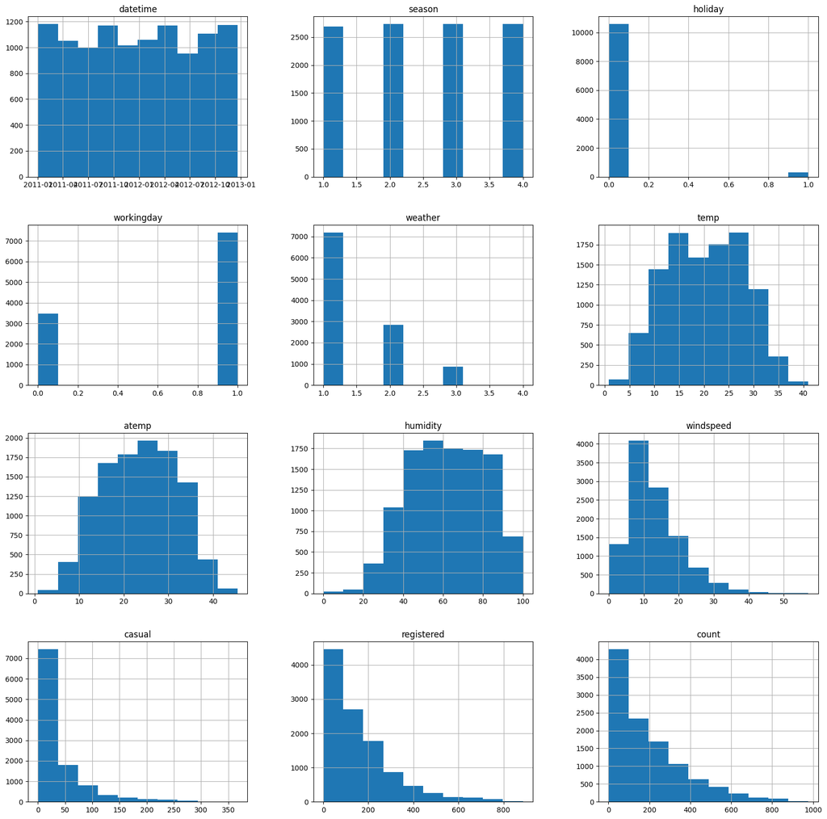

```python
# Create a histogram of all features to show the distribution of each one relative to the data. This is part of the exploritory data analysis
train.hist(figsize=(20, 20));
```

```python
# create a new feature
train['year'] = train['datetime'].dt.year
train['month'] = train['datetime'].dt.month
train['day'] = train['datetime'].dt.day
train['hour'] = train['datetime'].dt.hour

test['year'] = test['datetime'].dt.year
test['month'] = test['datetime'].dt.month
test['day'] = test['datetime'].dt.day
test['hour'] = test['datetime'].dt.hour
```

## Make category types for these so models know they are not just numbers

- AutoGluon originally sees these as ints, but in reality they are int representations of a category.
- Setting the dtype to category will classify these as categories in AutoGluon.

```python
train["season"] = train["season"].astype("category")
train["weather"] = train["weather"].astype("category")
test["season"] = test["season"].astype("category")
test["weather"] = test["weather"].astype("category")
```

```python
train.corr()
```

|  | holiday | workingday | temp | atemp | humidity | windspeed | casual | registered | count | year | month | day | hour |
| --- | --- | --- | --- | --- | --- | --- | --- | --- | --- | --- | --- | --- | --- |
| holiday | 1.000000 | -0.250491 | 0.000295 | -0.005215 | 0.001929 | 0.008409 | 0.043799 | -0.020956 | -0.005393 | 0.012021 | 0.001731 | -0.015877 | -0.000354 |
| workingday | -0.250491 | 1.000000 | 0.029966 | 0.024660 | -0.010880 | 0.013373 | -0.319111 | 0.119460 | 0.011594 | -0.002482 | -0.003394 | 0.009829 | 0.002780 |
| temp | 0.000295 | 0.029966 | 1.000000 | 0.984948 | -0.064949 | -0.017852 | 0.467097 | 0.318571 | 0.394454 | 0.061226 | 0.257589 | 0.015551 | 0.145430 |
| atemp | -0.005215 | 0.024660 | 0.984948 | 1.000000 | -0.043536 | -0.057473 | 0.462067 | 0.314635 | 0.389784 | 0.058540 | 0.264173 | 0.011866 | 0.140343 |
| humidity | 0.001929 | -0.010880 | -0.064949 | -0.043536 | 1.000000 | -0.318607 | -0.348187 | -0.265458 | -0.317371 | -0.078606 | 0.204537 | -0.011335 | -0.278011 |
| windspeed | 0.008409 | 0.013373 | -0.017852 | -0.057473 | -0.318607 | 1.000000 | 0.092276 | 0.091052 | 0.101369 | -0.015221 | -0.150192 | 0.036157 | 0.146631 |
| casual | 0.043799 | -0.319111 | 0.467097 | 0.462067 | -0.348187 | 0.092276 | 1.000000 | 0.497250 | 0.690414 | 0.145241 | 0.092722 | 0.014109 | 0.302045 |
| registered | -0.020956 | 0.119460 | 0.318571 | 0.314635 | -0.265458 | 0.091052 | 0.497250 | 1.000000 | 0.970948 | 0.264265 | 0.169451 | 0.019111 | 0.380540 |
| count | -0.005393 | 0.011594 | 0.394454 | 0.389784 | -0.317371 | 0.101369 | 0.690414 | 0.970948 | 1.000000 | 0.260403 | 0.166862 | 0.019826 | 0.400601 |
| year | 0.012021 | -0.002482 | 0.061226 | 0.058540 | -0.078606 | -0.015221 | 0.145241 | 0.264265 | 0.260403 | 1.000000 | -0.004932 | 0.001800 | -0.004234 |
| month | 0.001731 | -0.003394 | 0.257589 | 0.264173 | 0.204537 | -0.150192 | 0.092722 | 0.169451 | 0.166862 | -0.004932 | 1.000000 | 0.001974 | -0.006818 |
| day | -0.015877 | 0.009829 | 0.015551 | 0.011866 | -0.011335 | 0.036157 | 0.014109 | 0.019111 | 0.019826 | 0.001800 | 0.001974 | 1.000000 | 0.001132 |
| hour | -0.000354 | 0.002780 | 0.145430 | 0.140343 | -0.278011 | 0.146631 | 0.302045 | 0.380540 | 0.400601 | -0.004234 | -0.006818 | 0.001132 | 1.000000 |

```python
# Drop highly correlated features
train.drop('atemp', axis=1, inplace=True)
test.drop('atemp', axis=1, inplace=True)
```

```python
# View are new feature
train.head()
```

|  | datetime | season | holiday | workingday | weather | temp | humidity | windspeed | casual | registered | count | year | month | day | hour |
| --- | --- | --- | --- | --- | --- | --- | --- | --- | --- | --- | --- | --- | --- | --- | --- |
| 0 | 2011-01-01 00:00:00 | 1 | 0 | 0 | 1 | 9.84 | 81 | 0.0 | 3 | 13 | 16 | 2011 | 1 | 1 | 0 |
| 1 | 2011-01-01 01:00:00 | 1 | 0 | 0 | 1 | 9.02 | 80 | 0.0 | 8 | 32 | 40 | 2011 | 1 | 1 | 1 |
| 2 | 2011-01-01 02:00:00 | 1 | 0 | 0 | 1 | 9.02 | 80 | 0.0 | 5 | 27 | 32 | 2011 | 1 | 1 | 2 |
| 3 | 2011-01-01 03:00:00 | 1 | 0 | 0 | 1 | 9.84 | 75 | 0.0 | 3 | 10 | 13 | 2011 | 1 | 1 | 3 |
| 4 | 2011-01-01 04:00:00 | 1 | 0 | 0 | 1 | 9.84 | 75 | 0.0 | 0 | 1 | 1 | 2011 | 1 | 1 | 4 |

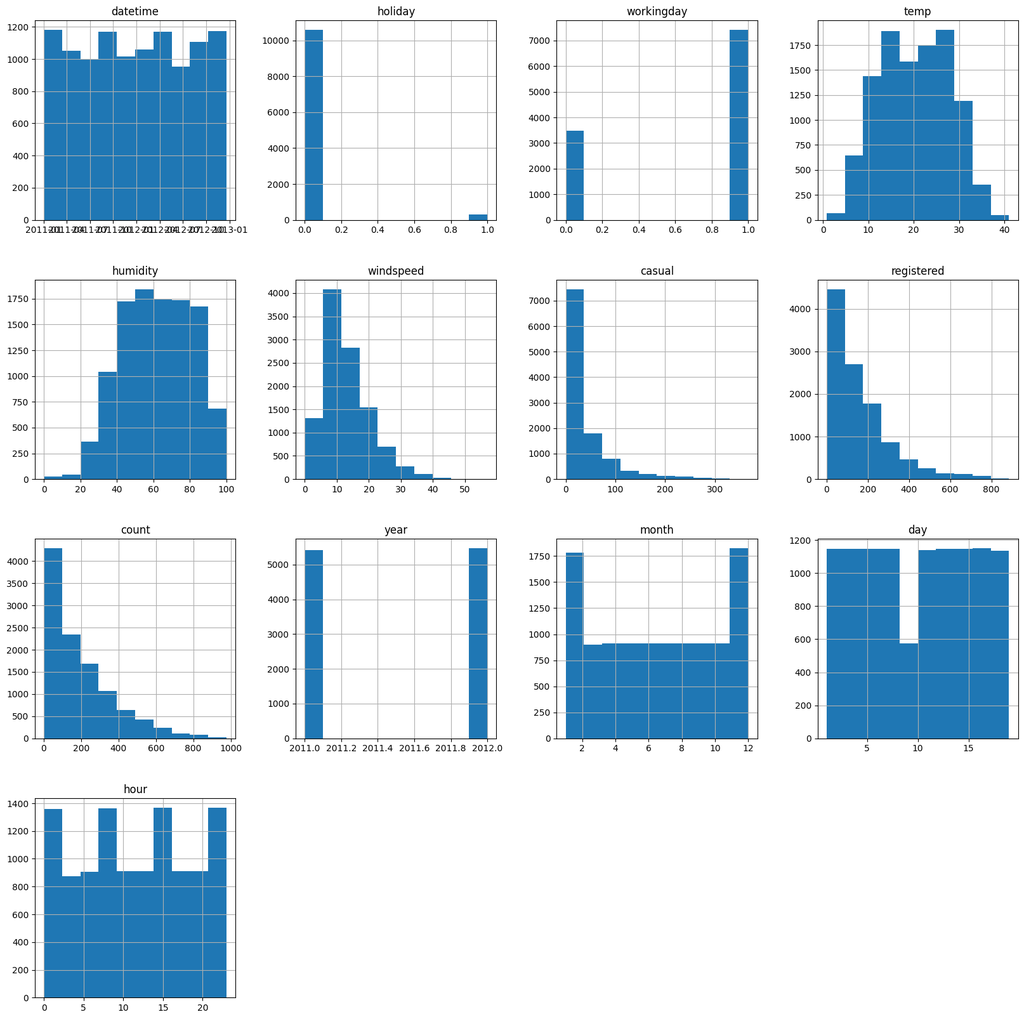

```python
# View histogram of all features again now with the new features
train.hist(figsize=(20, 20));
```

```python
# Add feature 'day_type' to the dataset
train["day_type"]=""
train.loc[(train.holiday==1),"day_type"] = "holiday"
train.loc[((train.holiday==0) & (train.workingday==1)), "day_type"] = "weekday"
train.loc[((train.holiday==0) & (train.workingday==0)), "day_type"] = "weekend"

test["day_type"]=""
test.loc[(test.holiday==1),"day_type"] = "holiday"
test.loc[((test.holiday==0) & (test.workingday==1)), "day_type"] = "weekday"
test.loc[((test.holiday==0) & (test.workingday==0)), "day_type"] = "weekend"

train["day_type"] = train["day_type"].astype("category")
test["day_type"] = test["day_type"].astype("category")
```

```python
train.head()
```

|  | datetime | season | holiday | workingday | weather | temp | humidity | windspeed | casual | registered | count | year | month | day | hour | day_type |
| --- | --- | --- | --- | --- | --- | --- | --- | --- | --- | --- | --- | --- | --- | --- | --- | --- |
| 0 | 2011-01-01 00:00:00 | 1 | 0 | 0 | 1 | 9.84 | 81 | 0.0 | 3 | 13 | 16 | 2011 | 1 | 1 | 0 | weekend |
| 1 | 2011-01-01 01:00:00 | 1 | 0 | 0 | 1 | 9.02 | 80 | 0.0 | 8 | 32 | 40 | 2011 | 1 | 1 | 1 | weekend |
| 2 | 2011-01-01 02:00:00 | 1 | 0 | 0 | 1 | 9.02 | 80 | 0.0 | 5 | 27 | 32 | 2011 | 1 | 1 | 2 | weekend |
| 3 | 2011-01-01 03:00:00 | 1 | 0 | 0 | 1 | 9.84 | 75 | 0.0 | 3 | 10 | 13 | 2011 | 1 | 1 | 3 | weekend |
| 4 | 2011-01-01 04:00:00 | 1 | 0 | 0 | 1 | 9.84 | 75 | 0.0 | 0 | 1 | 1 | 2011 | 1 | 1 | 4 | weekend |

## Step 5: Rerun the model with the same settings as before, just with more features

```python
predictor_new_features = TabularPredictor(label='count', eval_metric='root_mean_squared_error', problem_type='regression', learner_kwargs={'ignored_columns':["casual", "registered"]}).fit(train_data=train, presets='best_quality', time_limit=600)
```

```
No path specified. Models will be saved in: "AutogluonModels/ag-20230530_215100/"
Presets specified: ['best_quality']
Stack configuration (auto_stack=True): num_stack_levels=1, num_bag_folds=8, num_bag_sets=20
Beginning AutoGluon training ... Time limit = 600s
AutoGluon will save models to "AutogluonModels/ag-20230530_215100/"
AutoGluon Version:  0.7.0
Python Version:     3.9.16
Operating System:   Darwin
Platform Machine:   arm64
Platform Version:   Darwin Kernel Version 22.6.0: Mon May  8 23:12:01 PDT 2023; root:xnu-8796.140.12.505.1~5/RELEASE_ARM64_T8112
Train Data Rows:    10886
Train Data Columns: 15
Label Column: count
Preprocessing data ...
Using Feature Generators to preprocess the data ...
Dropping user-specified ignored columns: ['casual', 'registered']
Fitting AutoMLPipelineFeatureGenerator...
	Available Memory:                    1854.16 MB
	Train Data (Original)  Memory Usage: 0.9 MB (0.0% of available memory)
	Inferring data type of each feature based on column values. Set feature_metadata_in to manually specify special dtypes of the features.
	Stage 1 Generators:
		Fitting AsTypeFeatureGenerator...
			Note: Converting 3 features to boolean dtype as they only contain 2 unique values.
	Stage 2 Generators:
		Fitting FillNaFeatureGenerator...
	Stage 3 Generators:
		Fitting IdentityFeatureGenerator...
		Fitting CategoryFeatureGenerator...
			Fitting CategoryMemoryMinimizeFeatureGenerator...
		Fitting DatetimeFeatureGenerator...
	Stage 4 Generators:
		Fitting DropUniqueFeatureGenerator...
	Types of features in original data (raw dtype, special dtypes):
		('category', []) : 3 | ['season', 'weather', 'day_type']
		('datetime', []) : 1 | ['datetime']
		('float', [])    : 2 | ['temp', 'windspeed']
		('int', [])      : 7 | ['holiday', 'workingday', 'humidity', 'year', 'month', ...]
	Types of features in processed data (raw dtype, special dtypes):
		('category', [])             : 3 | ['season', 'weather', 'day_type']
		('float', [])                : 2 | ['temp', 'windspeed']
		('int', [])                  : 4 | ['humidity', 'month', 'day', 'hour']
		('int', ['bool'])            : 3 | ['holiday', 'workingday', 'year']
		('int', ['datetime_as_int']) : 5 | ['datetime', 'datetime.year', 'datetime.month', 'datetime.day', 'datetime.dayofweek']
	0.1s = Fit runtime
	13 features in original data used to generate 17 features in processed data.
	Train Data (Processed) Memory Usage: 1.02 MB (0.1% of available memory)
Data preprocessing and feature engineering runtime = 0.08s ...
AutoGluon will gauge predictive performance using evaluation metric: 'root_mean_squared_error'
	This metric's sign has been flipped to adhere to being higher_is_better. The metric score can be multiplied by -1 to get the metric value.
	To change this, specify the eval_metric parameter of Predictor()
AutoGluon will fit 2 stack levels (L1 to L2) ...
Fitting 11 L1 models ...
Fitting model: KNeighborsUnif_BAG_L1 ... Training model for up to 399.85s of the 599.92s of remaining time.
	-101.5882	 = Validation score   (-root_mean_squared_error)
	0.01s	 = Training   runtime
	0.01s	 = Validation runtime
Fitting model: KNeighborsDist_BAG_L1 ... Training model for up to 399.8s of the 599.88s of remaining time.
	-84.1464	 = Validation score   (-root_mean_squared_error)
	0.01s	 = Training   runtime
	0.01s	 = Validation runtime
Fitting model: LightGBMXT_BAG_L1 ... Training model for up to 399.76s of the 599.83s of remaining time.
	Fitting 8 child models (S1F1 - S1F8) | Fitting with SequentialLocalFoldFittingStrategy
```

```
[1000]	valid_set's rmse: 35.532
[2000]	valid_set's rmse: 33.7781
[3000]	valid_set's rmse: 33.4653
[4000]	valid_set's rmse: 33.4158
[5000]	valid_set's rmse: 33.4367
[1000]	valid_set's rmse: 36.9302
[2000]	valid_set's rmse: 34.9906
[3000]	valid_set's rmse: 34.4646
[4000]	valid_set's rmse: 34.3891
[5000]	valid_set's rmse: 34.4072
```

```
	Ran out of time, early stopping on iteration 5506. Best iteration is:
	[5246]	valid_set's rmse: 34.3684
```

```
[1000]	valid_set's rmse: 36.0733
[2000]	valid_set's rmse: 34.1783
[3000]	valid_set's rmse: 33.7763
[4000]	valid_set's rmse: 33.5457
[5000]	valid_set's rmse: 33.461
```

```
	Ran out of time, early stopping on iteration 5903. Best iteration is:
	[5828]	valid_set's rmse: 33.4179
```

[output not shown]

```
	-34.6389	 = Validation score   (-root_mean_squared_error)
	315.59s	 = Training   runtime
	2.31s	 = Validation runtime
Fitting model: LightGBM_BAG_L1 ... Training model for up to 78.46s of the 278.53s of remaining time.
	Fitting 8 child models (S1F1 - S1F8) | Fitting with SequentialLocalFoldFittingStrategy
```

```
[1000]	valid_set's rmse: 33.0574
```

```
	Ran out of time, early stopping on iteration 1328. Best iteration is:
	[1321]	valid_set's rmse: 32.8316
```

```
[1000]	valid_set's rmse: 32.706
```

```
	Ran out of time, early stopping on iteration 1358. Best iteration is:
	[1321]	valid_set's rmse: 32.2751
```

```
[1000]	valid_set's rmse: 32.2299
```

```
	Ran out of time, early stopping on iteration 1413. Best iteration is:
	[1410]	valid_set's rmse: 31.9004
```

```
[1000]	valid_set's rmse: 35.9168
```

```
	Ran out of time, early stopping on iteration 1470. Best iteration is:
	[1467]	valid_set's rmse: 35.4878
```

```
[1000]	valid_set's rmse: 36.258
```

```
	Ran out of time, early stopping on iteration 1530. Best iteration is:
	[1496]	valid_set's rmse: 36.0226
```

```
[1000]	valid_set's rmse: 31.2003
```

```
	Ran out of time, early stopping on iteration 1619. Best iteration is:
	[1615]	valid_set's rmse: 30.9583
```

```
[1000]	valid_set's rmse: 37.9663
```

```
	Ran out of time, early stopping on iteration 1757. Best iteration is:
	[1595]	valid_set's rmse: 37.6414
```

```
[1000]	valid_set's rmse: 35.3481
[2000]	valid_set's rmse: 35.0963
```

```
	Ran out of time, early stopping on iteration 2125. Best iteration is:
	[2037]	valid_set's rmse: 35.0738
	-34.0945	 = Validation score   (-root_mean_squared_error)
	74.42s	 = Training   runtime
	0.46s	 = Validation runtime
Fitting model: RandomForestMSE_BAG_L1 ... Training model for up to 2.63s of the 202.7s of remaining time.
	-38.163	 = Validation score   (-root_mean_squared_error)
	4.91s	 = Training   runtime
	0.42s	 = Validation runtime
Completed 1/20 k-fold bagging repeats ...
Fitting model: WeightedEnsemble_L2 ... Training model for up to 360.0s of the 197.04s of remaining time.
	-32.4584	 = Validation score   (-root_mean_squared_error)
	0.15s	 = Training   runtime
	0.0s	 = Validation runtime
Fitting 9 L2 models ...
Fitting model: LightGBMXT_BAG_L2 ... Training model for up to 196.87s of the 196.87s of remaining time.
	Fitting 8 child models (S1F1 - S1F8) | Fitting with SequentialLocalFoldFittingStrategy
```

```
[1000]	valid_set's rmse: 35.3548
[1000]	valid_set's rmse: 30.4236
[1000]	valid_set's rmse: 30.9993
[1000]	valid_set's rmse: 31.4307
```

```
	-31.5654	 = Validation score   (-root_mean_squared_error)
	50.82s	 = Training   runtime
	0.18s	 = Validation runtime
Fitting model: LightGBM_BAG_L2 ... Training model for up to 145.5s of the 145.5s of remaining time.
	Fitting 8 child models (S1F1 - S1F8) | Fitting with SequentialLocalFoldFittingStrategy
	-30.636	 = Validation score   (-root_mean_squared_error)
	28.09s	 = Training   runtime
	0.08s	 = Validation runtime
Fitting model: RandomForestMSE_BAG_L2 ... Training model for up to 117.19s of the 117.19s of remaining time.
	-32.0879	 = Validation score   (-root_mean_squared_error)
	9.23s	 = Training   runtime
	0.47s	 = Validation runtime
Fitting model: CatBoost_BAG_L2 ... Training model for up to 107.2s of the 107.19s of remaining time.
	Fitting 8 child models (S1F1 - S1F8) | Fitting with SequentialLocalFoldFittingStrategy
	Ran out of time, early stopping on iteration 1268.
	Ran out of time, early stopping on iteration 1221.
	Ran out of time, early stopping on iteration 1730.
	Ran out of time, early stopping on iteration 1818.
	-30.522	 = Validation score   (-root_mean_squared_error)
	100.43s	 = Training   runtime
	0.06s	 = Validation runtime
Fitting model: ExtraTreesMSE_BAG_L2 ... Training model for up to 6.63s of the 6.62s of remaining time.
	-31.6988	 = Validation score   (-root_mean_squared_error)
	3.74s	 = Training   runtime
	0.48s	 = Validation runtime
Fitting model: NeuralNetFastAI_BAG_L2 ... Training model for up to 2.03s of the 2.03s of remaining time.
	Fitting 8 child models (S1F1 - S1F8) | Fitting with SequentialLocalFoldFittingStrategy
	Time limit exceeded... Skipping NeuralNetFastAI_BAG_L2.
Fitting model: XGBoost_BAG_L2 ... Training model for up to 1.71s of the 1.7s of remaining time.
	Fitting 8 child models (S1F1 - S1F8) | Fitting with SequentialLocalFoldFittingStrategy
	Time limit exceeded... Skipping XGBoost_BAG_L2.
Fitting model: NeuralNetTorch_BAG_L2 ... Training model for up to 0.2s of the 0.19s of remaining time.
	Fitting 8 child models (S1F1 - S1F8) | Fitting with SequentialLocalFoldFittingStrategy
<__array_function__ internals>:200: RuntimeWarning: invalid value encountered in cast
<__array_function__ internals>:200: RuntimeWarning: invalid value encountered in cast
	Time limit exceeded... Skipping NeuralNetTorch_BAG_L2.
Completed 1/20 k-fold bagging repeats ...
Fitting model: WeightedEnsemble_L3 ... Training model for up to 360.0s of the -0.02s of remaining time.
	-30.267	 = Validation score   (-root_mean_squared_error)
	0.2s	 = Training   runtime
	0.0s	 = Validation runtime
AutoGluon training complete, total runtime = 600.24s ... Best model: "WeightedEnsemble_L3"
TabularPredictor saved. To load, use: predictor = TabularPredictor.load("AutogluonModels/ag-20230530_215100/")
```

```python
predictor_new_features.fit_summary()
```

```
*** Summary of fit() ***
Estimated performance of each model:
                     model   score_val  pred_time_val    fit_time  pred_time_val_marginal  fit_time_marginal  stack_level  can_infer  fit_order
0      WeightedEnsemble_L3  -30.266960       3.535026  574.493432                0.000371           0.196412            3       True         12
1          CatBoost_BAG_L2  -30.522012       3.280654  495.384197                0.056638         100.433733            2       True         10
2          LightGBM_BAG_L2  -30.635968       3.302034  423.043439                0.078018          28.092975            2       True          8
3        LightGBMXT_BAG_L2  -31.565371       3.399998  445.770312                0.175983          50.819848            2       True          7
4     ExtraTreesMSE_BAG_L2  -31.698793       3.702953  398.688948                0.478937           3.738484            2       True         11
5   RandomForestMSE_BAG_L2  -32.087887       3.694937  404.183618                0.470921           9.233154            2       True          9
6      WeightedEnsemble_L2  -32.458373       3.210755  395.090552                0.000335           0.150392            2       True          6
7          LightGBM_BAG_L1  -34.094473       0.463597   74.420888                0.463597          74.420888            1       True          4
8        LightGBMXT_BAG_L1  -34.638879       2.308886  315.592977                2.308886         315.592977            1       True          3
9   RandomForestMSE_BAG_L1  -38.163021       0.424666    4.914523                0.424666           4.914523            1       True          5
10   KNeighborsDist_BAG_L1  -84.146423       0.013272    0.011772                0.013272           0.011772            1       True          2
11   KNeighborsUnif_BAG_L1 -101.588176       0.013596    0.010304                0.013596           0.010304            1       True          1
Number of models trained: 12
Types of models trained:
{'StackerEnsembleModel_KNN', 'StackerEnsembleModel_LGB', 'WeightedEnsembleModel', 'StackerEnsembleModel_XT', 'StackerEnsembleModel_RF', 'StackerEnsembleModel_CatBoost'}
Bagging used: True  (with 8 folds)
Multi-layer stack-ensembling used: True  (with 3 levels)
Feature Metadata (Processed):
(raw dtype, special dtypes):
('category', [])             : 3 | ['season', 'weather', 'day_type']
('float', [])                : 2 | ['temp', 'windspeed']
('int', [])                  : 4 | ['humidity', 'month', 'day', 'hour']
('int', ['bool'])            : 3 | ['holiday', 'workingday', 'year']
('int', ['datetime_as_int']) : 5 | ['datetime', 'datetime.year', 'datetime.month', 'datetime.day', 'datetime.dayofweek']
*** End of fit() summary ***
```

```
{'model_types': {'KNeighborsUnif_BAG_L1': 'StackerEnsembleModel_KNN',
  'KNeighborsDist_BAG_L1': 'StackerEnsembleModel_KNN',
  'LightGBMXT_BAG_L1': 'StackerEnsembleModel_LGB',
  'LightGBM_BAG_L1': 'StackerEnsembleModel_LGB',
  'RandomForestMSE_BAG_L1': 'StackerEnsembleModel_RF',
  'WeightedEnsemble_L2': 'WeightedEnsembleModel',
  'LightGBMXT_BAG_L2': 'StackerEnsembleModel_LGB',
  'LightGBM_BAG_L2': 'StackerEnsembleModel_LGB',
  'RandomForestMSE_BAG_L2': 'StackerEnsembleModel_RF',
  'CatBoost_BAG_L2': 'StackerEnsembleModel_CatBoost',
  'ExtraTreesMSE_BAG_L2': 'StackerEnsembleModel_XT',
  'WeightedEnsemble_L3': 'WeightedEnsembleModel'},
 'model_performance': {'KNeighborsUnif_BAG_L1': -101.58817625927213,
  'KNeighborsDist_BAG_L1': -84.14642264302962,
  'LightGBMXT_BAG_L1': -34.638879464206475,
  'LightGBM_BAG_L1': -34.09447269431622,
  'RandomForestMSE_BAG_L1': -38.163020972186565,
  'WeightedEnsemble_L2': -32.45837255949268,
  'LightGBMXT_BAG_L2': -31.565371259965286,
  'LightGBM_BAG_L2': -30.635967795853038,
  'RandomForestMSE_BAG_L2': -32.08788719061764,
  'CatBoost_BAG_L2': -30.522012386835705,
  'ExtraTreesMSE_BAG_L2': -31.69879306781693,
  'WeightedEnsemble_L3': -30.26695957677592},
 'model_best': 'WeightedEnsemble_L3',
 'model_paths': {'KNeighborsUnif_BAG_L1': 'AutogluonModels/ag-20230530_215100/models/KNeighborsUnif_BAG_L1/',
  'KNeighborsDist_BAG_L1': 'AutogluonModels/ag-20230530_215100/models/KNeighborsDist_BAG_L1/',
  'LightGBMXT_BAG_L1': 'AutogluonModels/ag-20230530_215100/models/LightGBMXT_BAG_L1/',
  'LightGBM_BAG_L1': 'AutogluonModels/ag-20230530_215100/models/LightGBM_BAG_L1/',
  'RandomForestMSE_BAG_L1': 'AutogluonModels/ag-20230530_215100/models/RandomForestMSE_BAG_L1/',
  'WeightedEnsemble_L2': 'AutogluonModels/ag-20230530_215100/models/WeightedEnsemble_L2/',
  'LightGBMXT_BAG_L2': 'AutogluonModels/ag-20230530_215100/models/LightGBMXT_BAG_L2/',
  'LightGBM_BAG_L2': 'AutogluonModels/ag-20230530_215100/models/LightGBM_BAG_L2/',
  'RandomForestMSE_BAG_L2': 'AutogluonModels/ag-20230530_215100/models/RandomForestMSE_BAG_L2/',
  'CatBoost_BAG_L2': 'AutogluonModels/ag-20230530_215100/models/CatBoost_BAG_L2/',
  'ExtraTreesMSE_BAG_L2': 'AutogluonModels/ag-20230530_215100/models/ExtraTreesMSE_BAG_L2/',
  'WeightedEnsemble_L3': 'AutogluonModels/ag-20230530_215100/models/WeightedEnsemble_L3/'},
 'model_fit_times': {'KNeighborsUnif_BAG_L1': 0.010303974151611328,
  'KNeighborsDist_BAG_L1': 0.011771917343139648,
  'LightGBMXT_BAG_L1': 315.59297704696655,
```

[output cut: 102 more lines]

```
 11                0.013596           0.010304            1       True

     fit_order
 0          12
 1          10
 2           8
 3           7
 4          11
 5           9
 6           6
 7           4
 8           3
 9           5
 10          2
 11          1  }
```

```python
# Set all negative values to zero
predictions_new_features = predictor_new_features.predict(test)
predictions_new_features[predictions_new_features < 0] = 0
```

```python
# Same submitting predictions
submission_new_features = pd.read_csv("sampleSubmission.csv", parse_dates=["datetime"])
submission_new_features["count"] = predictions_new_features
submission_new_features.to_csv("submission_new_features.csv", index=False)
```

```python
!kaggle competitions submit -c bike-sharing-demand -f submission_new_features.csv -m "new features"
```

```
Successfully submitted to Bike Sharing Demand
```

```python
!kaggle competitions submissions -c bike-sharing-demand | tail -n +1 | head -n 6
```

```
fileName                     date                 description           status    publicScore  privateScore
---------------------------  -------------------  --------------------  --------  -----------  ------------
submission_new_features.csv  2023-05-30 22:01:20  new features          complete  0.72212      0.72212
submission.csv               2023-05-30 21:50:54  first raw submission  complete  1.80025      1.80025
```